# Effect of herbivory and nutrients on Galapagos’ algae

Esteban Agudo

8/25/2020

```r
library(dplyr)
library(tidyr)
library(ggplot2)
library(ggpubr)
library(viridis)
library(hrbrthemes)
library(gridExtra)
library(stats)
library(kableExtra)
library(flextable)
library(reshape2)
#library(xlsx)
library(cowplot)
library(performance)
library(MASS)
library(openxlsx)
```

# Effect of herbivore exclussion and Nutrient additions on algae cover.

##Cold season Uploading data for the cold season, then preparing data for plotting.

```r
cold_2019<-read.csv(file="AlgaeCover_Cold2019.csv", header=T)
cold_2019<-na.omit(cold_2019)
cold_2019$Week<-as.factor(cold_2019$Week)
cold_2019$Cage.Number<-as.factor(cold_2019$Cage.Number)

#Changing the names and reordering levels of the factor Nutrient additions.
cold_2019$N <- factor(cold_2019$N, levels = c("No N", "N+"))
levels(cold_2019$N) <- (c("No N" = "Ambient nutrients", "N+" = "Nutrient additions"))

#Reordering  the levels of the treatments
cold_2019$Treatment <- factor(cold_2019$Treatment, levels = c("All present", "Fish only", "Urchins Only", "None present"))

#Changing the name of the levels in treatment
levels(cold_2019$Treatment)<-(c("All present"="Open pizzas", "Fish only"="Fish access", "Urchins Only"="Fish exclusions", "None present"="Full exclusions"))
```

Estimating values and preparing plot.

```r
cold_2019_average<-cold_2019 %>%
 dplyr::select(Cage.Number, Treatment, N, Week, Algae) %>%
group_by(Week,Treatment, N) %>%
summarise(mean=mean(Algae), se=sd(Algae)/sqrt(length(Algae))) %>%
  filter(Treatment!= "Fish access") #Removing fish treatment
```

```r
# Ploting weekly changes for the cold season
colour.palette <- c("#999999", "#E69F00", "#56B4E9", "#009E73", "#F0E442", "#0072B2", "#D55E00", "#CC79A7")

Algae_CoverColdSeason <- ggplot(cold_2019_average, aes(x=Week, y=mean, colour=Treatment, group=Treatment)) +
  geom_errorbar(aes(ymin=mean-se, ymax=mean+se), width=.8, position=position_dodge(width=0.4), linetype="dotted", size=.4) +
  geom_line(position=position_dodge(width=0.4)) +
  geom_point(size = 2, position=position_dodge(width=0.4)) +
  facet_wrap(~N, nrow=1) +theme_bw()+theme(legend.position = "bottom") +
  theme(panel.grid.major = element_blank(), panel.grid.minor=element_blank()) +
  labs(y="Mean algae cover (%)", x="Sampling week") +
  scale_color_manual(values=colour.palette)
```

### Plotting_COLD

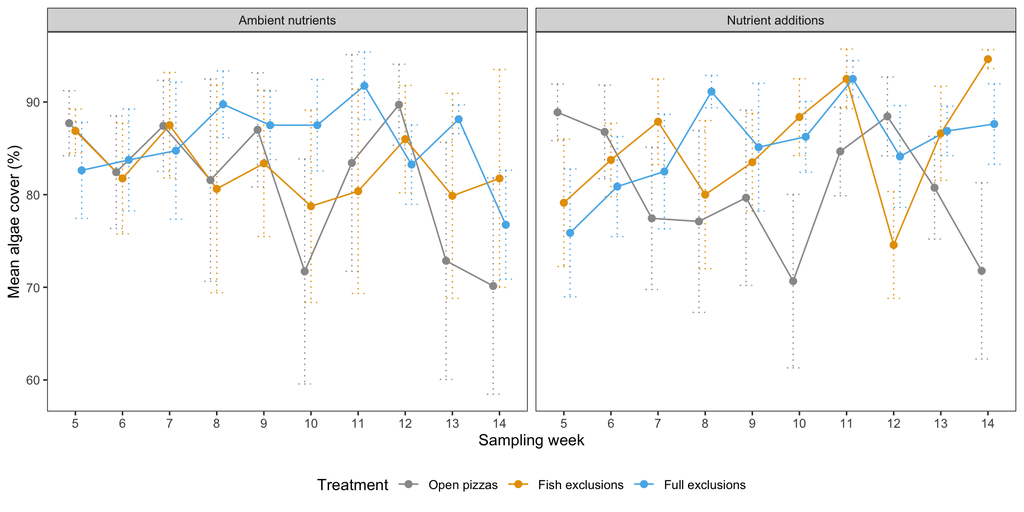

```r
Algae_CoverColdSeason
```

```r
#ggsave("AlgaeCover_ColdSeason.png", width = 20, height = 10, units = "cm", dpi = 300)
```

Figure 1: Effect of herbivore exclussion and Nutrient additions on weekly algae cover during cold season.

## Warm season

Loading and preparing data of the warm season

```r
#Loading and preparing data
warm_2020<-read.csv(file="AlgaeCover_Warm2020.csv", header=T)
warm_2020<-na.omit(warm_2020)
warm_2020$Week<-as.factor(warm_2020$Week)
warm_2020$Cage.Number<-as.factor(warm_2020$Cage.Number)

#Changing the names and reordering levels of the factor Nutrient additions.
warm_2020$N <- factor(warm_2020$N, levels = c("No N", "N+"))
levels(warm_2020$N) <- (c("No N" = "Ambient nutrients", "N+" = "Nutrient additions"))

#Reordering  the levels of the treatments
warm_2020$Treatment <- factor(warm_2020$Treatment, levels = c("All present", "Urchins Only", "None present"))

#Changing the name of the levels in treatment
levels(warm_2020$Treatment)<-(c("All present"="Open pizzas", "Urchins Only"="Fish exclusions", "None present"="Full exclusions"))
```

### Plotting_WARM

```r
warm_2020_average <- warm_2020 %>%
  dplyr::select(Cage.Number, Treatment, N, Week, Algae) %>%
group_by(Week,Treatment, N) %>%
summarise(mean=mean(Algae), se=sd(Algae)/sqrt(length(Algae)))
```

```r
AlgaeCover_HotSeason <- ggplot(warm_2020_average, aes(x=Week, y=mean, colour=Treatment, group=Treatment)) +
  geom_errorbar(aes(ymin=mean-se, ymax=mean+se), width=.8, position=position_dodge(width=0.4), linetype="dotted",size=.4)+
    geom_line(position=position_dodge(width=0.4)) +
    geom_point(size=2, position=position_dodge(width=0.4))+ facet_wrap(~N, nrow=1) +theme_bw()+theme(legend.position = "bottom")+ theme(panel.grid.major = element_blank(), panel.grid.minor = element_blank())+
  labs(y="Mean algae cover (%)", x="Sampling week")+
  scale_color_manual(values=colour.palette)
```

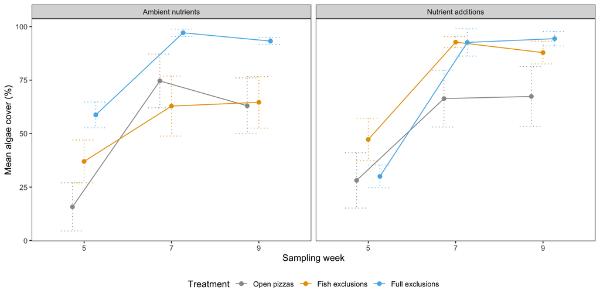

```r
AlgaeCover_HotSeason
```

```r
#ggsave("AlgaeCover_HotSeason.png", width = 18, height = 10, units = "cm", dpi = 300)
```

Figure 2: Effect of herbivore exclussion and Nutrient additions on algae cover during warm season.

##Ploting both together

```r
Cover_BothSeason <- ggarrange(Algae_CoverColdSeason, AlgaeCover_HotSeason, nrow=2, common.legend = TRUE, labels = c("A", "B"), hjust = -0.1, vjust = 1.5, legend="bottom") +
  theme(plot.background = element_rect(fill = "white", colour = NA))
#ggsave("Cover_BothSeason.png", width = 18, height = 17, units = "cm", dpi = 300)
```

## Colleen stat exploration:

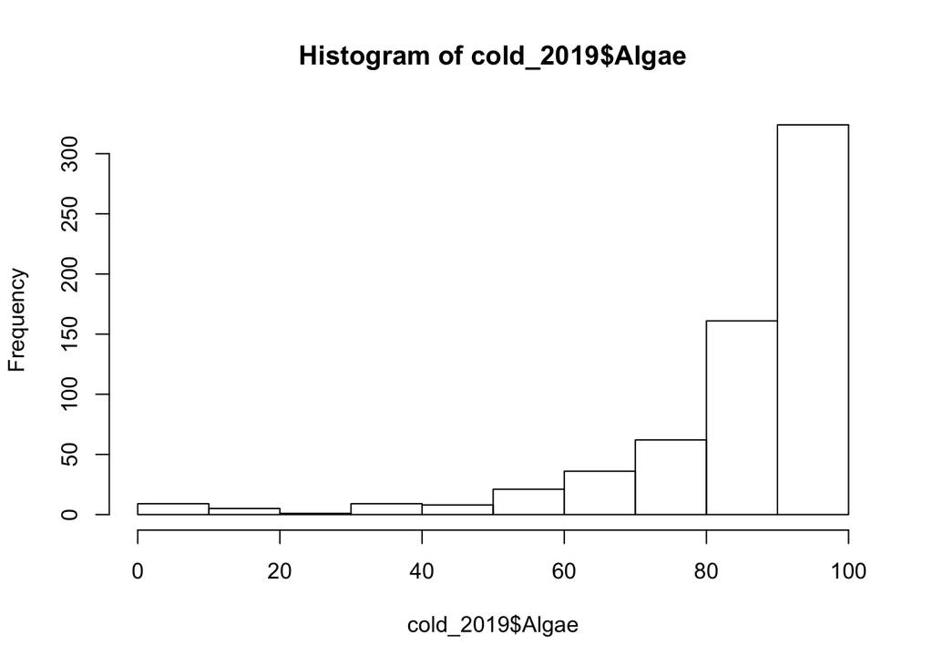

```r
## So these data are super non-normal!
hist(cold_2019$Algae)
```

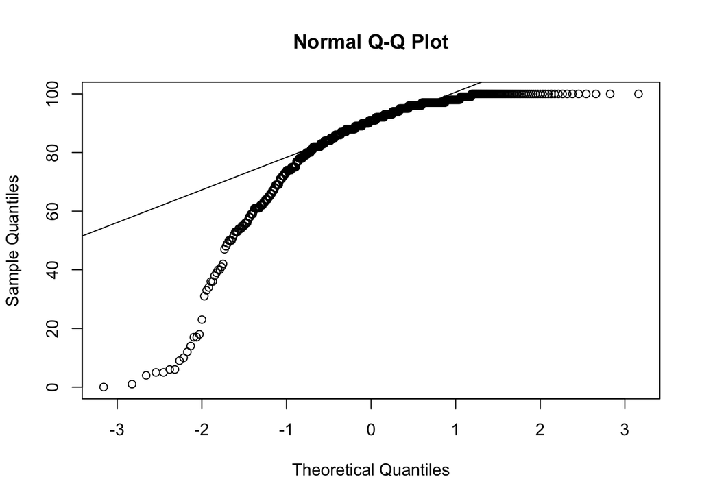

```r
qqnorm(cold_2019$Algae)
qqline(cold_2019$Algae)
```

```r
shapiro.test(cold_2019$Algae)
```

```
##
##  Shapiro-Wilk normality test
##
## data:  cold_2019$Algae
## W = 0.74002, p-value < 2.2e-16
```

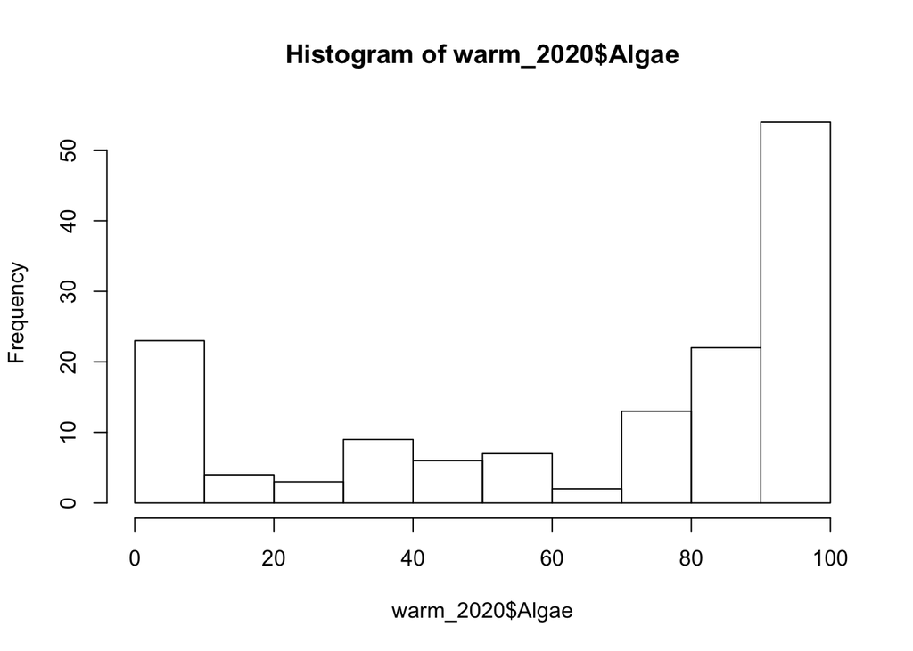

```r
hist(warm_2020$Algae)
```

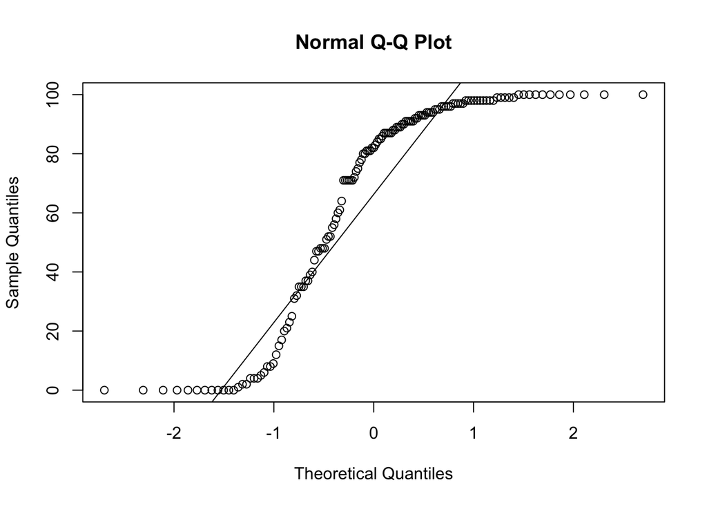

```r
qqnorm(warm_2020$Algae)
qqline(warm_2020$Algae)
```

```r
shapiro.test(warm_2020$Algae)
```

```
##
##  Shapiro-Wilk normality test
##
## data:  warm_2020$Algae
## W = 0.81868, p-value = 5.132e-12
```

# Effect of herbivore’s exclussion and Nutrient additions on algae weight.

Data uploading and preparation including changing names and reordering factors.

```r
## Loading Cold season data
AlgaeWeight_Cold2019 <- read.csv(file = "AlgaeWeight_Cold2019.csv")

#Reordering and renaming Factor: Nutrient
AlgaeWeight_Cold2019$N <- factor(AlgaeWeight_Cold2019$N, levels = c("No N", "N+"))
levels(AlgaeWeight_Cold2019$N) <- c("No N" = "Ambient nutrients", "N+" = "Nutrient additions")

#Reordering and renaming factor Treatment
AlgaeWeight_Cold2019$Treatment <- factor(AlgaeWeight_Cold2019$Treatment, levels = c("All present", "Fish Only", "Urchins Only", "None present"))
levels(AlgaeWeight_Cold2019$Treatment) <- (c("All present" = "Open pizzas", "Fish Only" = "Fish access", "Urchins Only" = "Fish exclusions", "None present" = "Full exclusions"))

AlgaeWeight_Cold2019 <- AlgaeWeight_Cold2019 %>%
  filter(Treatment != "Fish access") %>% #Removing exclussion treatment with access to fish
  filter(AFDW..g...preburn..postburn. != 0) %>% #Removing sampling units zeros
  droplevels()



## Loading Warm season data
AlgaeWeight_Warm2020 <- read.csv(file = "AlgaeWeight_Warm2020.csv")

#Reordering and renaming Factor: Nutrient
AlgaeWeight_Warm2020$N <- factor(AlgaeWeight_Warm2020$N, levels = c("No N", "N+"))
levels(AlgaeWeight_Warm2020$N) <- c("No N" = "Ambient nutrients", "N+" = "Nutrient additions")

#Reordering and renaming factor Treatment
AlgaeWeight_Warm2020$Treatment <- factor(AlgaeWeight_Warm2020$Treatment, levels = c("All present", "Urchins Only", "None Present"))
levels(AlgaeWeight_Warm2020$Treatment) <- (c("All present"="Open pizzas", "Urchins Only"="Fish exclusions", "None Present"="Full exclusions"))

AlgaeWeight_Warm2020 <- AlgaeWeight_Warm2020 %>%
  filter(AFDW..g...preburn..postburn. != 0) # Removing zeros
```

```r
AlgaeWeight_Cold2019_Average <- AlgaeWeight_Cold2019 %>%
  group_by(Treatment, N) %>%
  summarise(Mean_AlgaeWeight=mean(AFDW..g...preburn..postburn.),
            se=sd(AFDW..g...preburn..postburn.)/sqrt(length(AFDW..g...preburn..postburn.)))
AlgaeWeight_Warm2020_Average <- AlgaeWeight_Warm2020 %>%
  group_by(Treatment, N) %>%
  summarise(Mean_AlgaeWeight=mean(AFDW..g...preburn..postburn.),
            se=sd(AFDW..g...preburn..postburn.)/sqrt(length(AFDW..g...preburn..postburn.)))
```

### Ploting Box plots (using collen code) for cold season

```r
# Summarizing data for each plot in order
AlgaeWeight_Cold2019_sum <- AlgaeWeight_Cold2019 %>%
  group_by(Treatment, N) %>% # input your grouping variable (seperate by commas if more than one)
  summarize(mean = round(mean(AFDW..g...preburn..postburn., na.rm = TRUE), 2),
            max = round(max(AFDW..g...preburn..postburn., na.rm = TRUE), 2),
            min = round(min(AFDW..g...preburn..postburn., na.rm = TRUE), 2),
            sd = sd(AFDW..g...preburn..postburn., na.rm = TRUE),
            n = n(),
          se=sd / sqrt(n))%>%
  mutate(lowerci = mean - qt(1 - (0.05 / 2), n - 1) * se,
         upperci = mean + qt(1 - (0.05 / 2), n - 1) * se)
X <- AlgaeWeight_Cold2019_sum$N # item to plot on x-axis
#df <- AlgaeWeight_Cold2019_sum # dataframe containing your summary stats
colour <- AlgaeWeight_Cold2019_sum$Treatment # item to colour data by
overall.mean <- round(mean(AlgaeWeight_Cold2019$AFDW..g...preburn..postburn.), 2) # modify this to change location of dashed line
ylab <- "AFDW (g)" # input y-axis label here (put "" if you want to leave label blank)
xlab <- "" # input x-axis label here (put "" if you want to leave label blank)
title <- "" # overall plot title (put "" if no title)

colour.palette <- c("#999999", "#E69F00", "#56B4E9", "#009E73", "#F0E442", "#0072B2", "#D55E00", "#CC79A7")
# This is just a nicer (colour blind friendly) colour palette that avoids defaults
```

### Plotting: Algae weight during cold season

```r
P1 <- ggplot() +
  theme_bw() + # sets plot theme (removes gridlines, etc.)
  #geom_hline(yintercept = overall.mean, colour = "darkgrey", linetype = 2) + # dashed line
  geom_point(data = AlgaeWeight_Cold2019, aes(x =N , y = AFDW..g...preburn..postburn., colour = Treatment), shape = 1, alpha = 0.4,              position = position_jitterdodge(jitter.width = NULL, jitter.height = 0,dodge.width = 0.85)) +
  geom_errorbar(data = AlgaeWeight_Cold2019_sum, aes(x = X, ymin = mean-se, ymax = mean+se, colour = colour), size = 8, width = 0, alpha = 0.6, position = position_dodge(width = 0.85), show.legend = FALSE) + # this plots SE behind the mean, can use also CI with summarize
  geom_point(data = AlgaeWeight_Cold2019_sum, aes(x = X, y = mean, colour = colour), shape = "-", size = 20, position = position_dodge(width = 0.85)) + # plots the mean value
  scale_colour_manual(name = "", values = colour.palette) + # adds the colours for plotting
  ylab(ylab) + # y-axis label
  scale_y_continuous(expand=c(0,0), breaks=seq(0, 50, 10), limits = c(0, 50)) + # makes the y-axis display
  xlab(xlab) + # x-axis label
  ggtitle(title)+ # whole plot title
  theme(axis.text.x = element_text(size = 9.5),
        axis.title.y = element_text(size = 9.5, hjust = 0.6, vjust = 2.5),
        legend.position = "bottom",
        legend.text = element_text(size = 10),
        legend.key.size = unit(0.5, "cm"),
        legend.key.height = unit(0.5, "cm"),
        panel.grid = element_blank()) + #Legend theme
  guides(colour = guide_legend(override.aes = list(shape = 15, size=3)))
```

### Plotting effect herbivory and Nutrient additions on algae weight during warm season

```r
# summarizing
AlgaeWeight_Warm2020_sum <- AlgaeWeight_Warm2020 %>%
  group_by(Treatment, N) %>% # input your grouping variable (seperate by commas if more than one)
  summarize(mean = round(mean(AFDW..g...preburn..postburn., na.rm = TRUE), 2),
            max = round(max(AFDW..g...preburn..postburn., na.rm = TRUE), 2),
            min = round(min(AFDW..g...preburn..postburn., na.rm = TRUE), 2),
            sd = sd(AFDW..g...preburn..postburn., na.rm = TRUE),
            n = n(),
            se=sd/sqrt(n)) %>%
  mutate(lowerci = mean - qt(1 - (0.05 / 2), n - 1) * se,
         upperci = mean + qt(1 - (0.05 / 2), n - 1) * se)
```

Estimating values for plot

```r
X <- AlgaeWeight_Warm2020_sum$N # item to plot on x-axis
#df <- AlgaeWeight_Warm2020_sum # dataframe containing your summary stats
colour <- AlgaeWeight_Warm2020_sum$Treatment # item to colour data by
overall.mean <- round(mean(AlgaeWeight_Warm2020$AFDW..g...preburn..postburn.), 2) # modify this to change location of dashed line
ylab <- "AFDW (g)" # input y-axis label here (put "" if you want to leave label blank)
xlab <- "" # input x-axis label here (put "" if you want to leave label blank)
title <- "" # overall plot title (put "" if no title)

colour.palette <- c("#999999", "#E69F00", "#56B4E9", "#009E73", "#F0E442", "#0072B2", "#D55E00", "#CC79A7")
# This is just a nicer (colour blind friendly) colour palette that avoids defaults
```

Let’s build the same plot fot the warm season

```r
P2 <- ggplot() +
  theme_bw() + # sets plot theme (removes gridlines, etc.)
  theme(panel.border = element_rect(colour = "black", fill=NA, size=0.7)) + # adds box around plot area
  #geom_hline(yintercept = overall.mean, colour = "darkgrey", linetype = 2) + # dashed line
  geom_point(data = AlgaeWeight_Warm2020, aes(x =N , y = AFDW..g...preburn..postburn., colour = Treatment), shape = 1, alpha = 0.4,              position = position_jitterdodge(jitter.width = NULL, jitter.height = 0,dodge.width = 0.85)) +
  geom_errorbar(data = AlgaeWeight_Warm2020_sum, aes(x = X, ymin = mean-se, ymax = mean+se, colour = colour), size = 8, width = 0, alpha = 0.6, position = position_dodge(width = 0.85), show.legend = FALSE) + # this plots SE behind the mean-Can change a CI using CI in summarize
  geom_point(data = AlgaeWeight_Warm2020_sum, aes(x = X, y = mean, colour = colour), shape = "-", size = 20, position = position_dodge(width = 0.85)) + # plots the mean value
  scale_colour_manual(name = "", values = colour.palette) + # adds the colours for plotting
  ylab(ylab) + # y-axis label
  scale_y_continuous(expand=c(0,0), breaks=seq(0, 50, 10), limits = c(0, 50)) + # makes the y-axis display
  xlab(xlab) + # x-axis label
  ggtitle(title)+ #legend theme
  theme(axis.text.x = element_text(size = 9.5),
        axis.title.y = element_text(size = 9.5, hjust = 0.6, vjust = 2.5),
        legend.position = "bottom",
        legend.text = element_text(size = 10),
        legend.key.size = unit(0.5, "cm"),
        legend.key.height = unit(0.5, "cm"),
        panel.grid = element_blank()) + #Legend theme
    guides(colour = guide_legend(override.aes = list(shape = 15, size=3)))#Legend them
```

Comparison between the effect of herbivore exclussion and Nutrient additions across cold season and warm season.

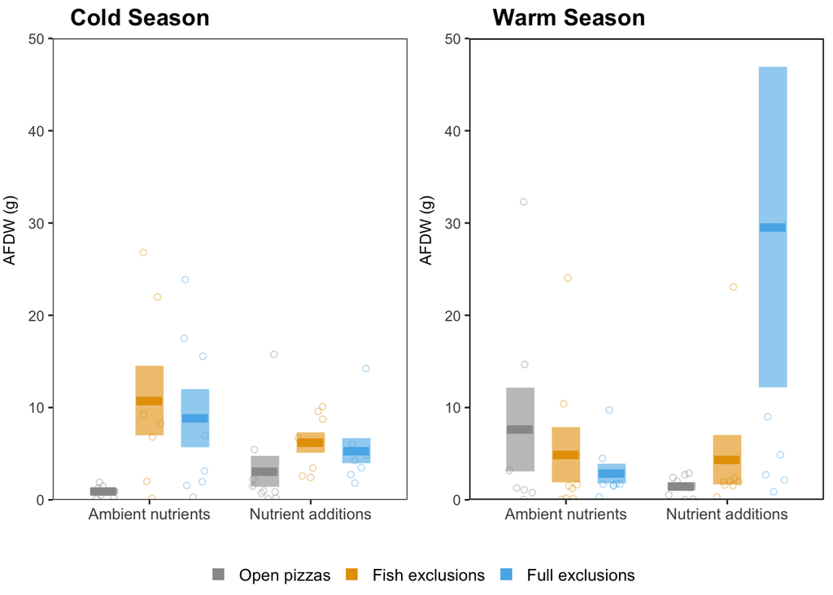

```r
Algae_weight <- ggarrange(P1, P2, nrow=1, common.legend = TRUE, labels = c("Cold Season", "Warm Season"), legend = "bottom") +
  theme(plot.background = element_rect(fill = "white", colour = NA))
Algae_weight
```

```r
#ggsave("AlgaeWeights_se.png", width = 22, height = 10, units = "cm", dpi = 300)
```

## Analysis of effect between herbivore exclussion and nutriend addition on algae weight

Let’s start by checking data distribution:

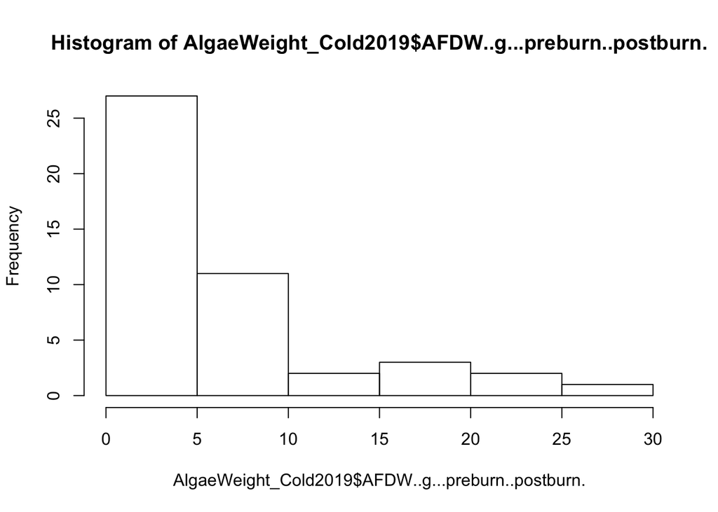

```r
hist(AlgaeWeight_Cold2019$AFDW..g...preburn..postburn.)
```

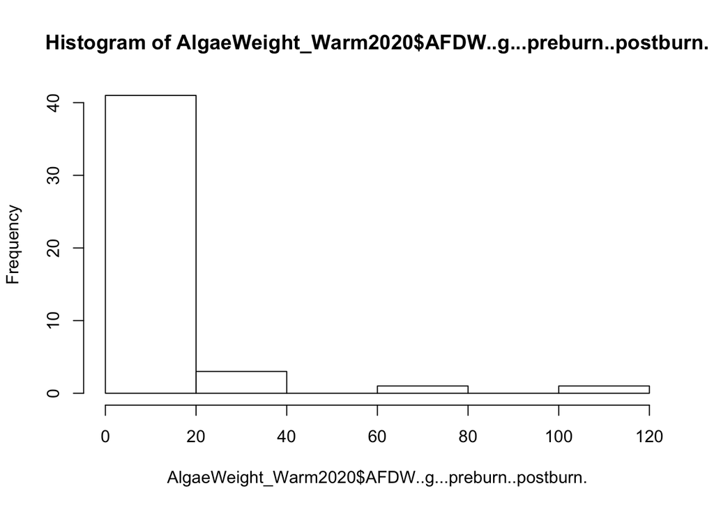

```r
hist(AlgaeWeight_Warm2020$AFDW..g...preburn..postburn.)
```

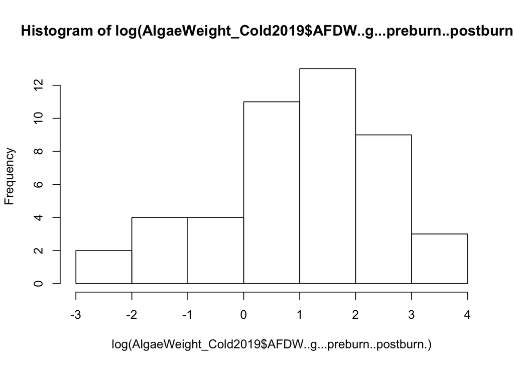

```r
#It is slightly skewed so a sqrt transformation can do the job
hist(log(AlgaeWeight_Cold2019$AFDW..g...preburn..postburn.))
```

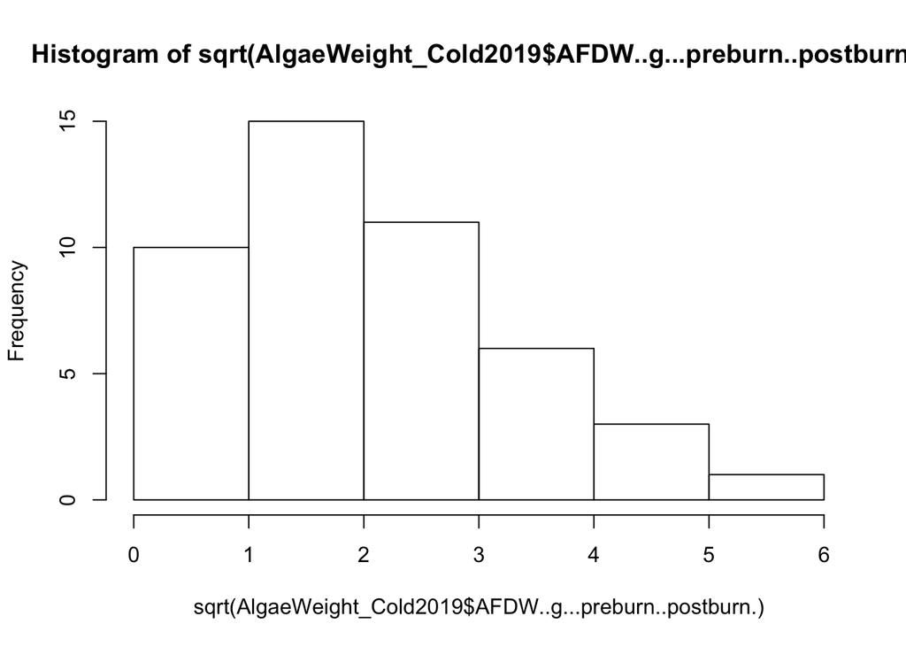

```r
hist(sqrt(AlgaeWeight_Cold2019$AFDW..g...preburn..postburn.))
```

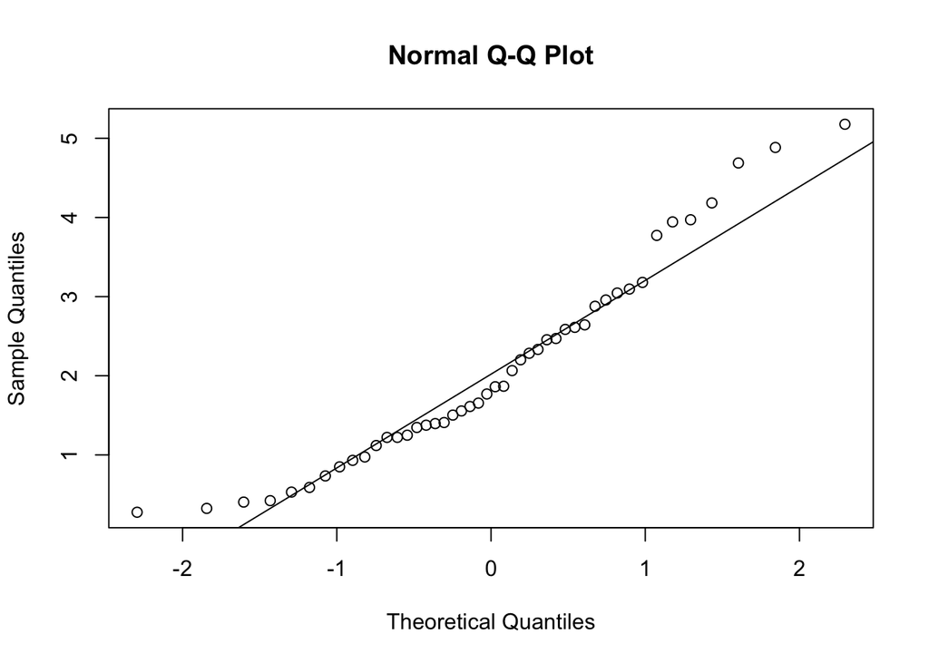

```r
qqnorm(sqrt(AlgaeWeight_Cold2019$AFDW..g...preburn..postburn.))
qqline(sqrt(AlgaeWeight_Cold2019$AFDW..g...preburn..postburn.))
```

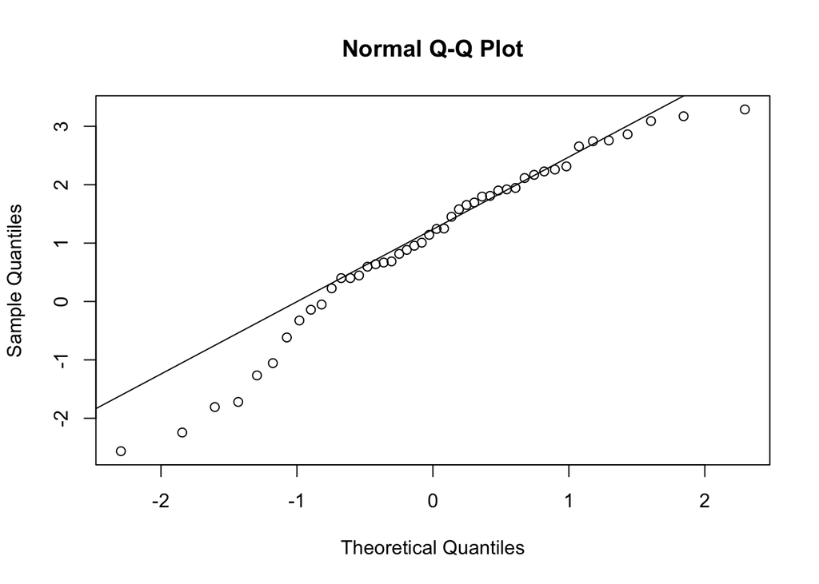

```r
qqnorm(log(AlgaeWeight_Cold2019$AFDW..g...preburn..postburn.+0.001))
qqline(log(AlgaeWeight_Cold2019$AFDW..g...preburn..postburn.+0.001))
```

```r
shapiro.test(AlgaeWeight_Cold2019$AFDW..g...preburn..postburn.)
```

```
##
##  Shapiro-Wilk normality test
##
## data:  AlgaeWeight_Cold2019$AFDW..g...preburn..postburn.
## W = 0.79449, p-value = 1.468e-06
```

```r
shapiro.test(sqrt(AlgaeWeight_Cold2019$AFDW..g...preburn..postburn.))
```

```
##
##  Shapiro-Wilk normality test
##
## data:  sqrt(AlgaeWeight_Cold2019$AFDW..g...preburn..postburn.)
## W = 0.94411, p-value = 0.02793
```

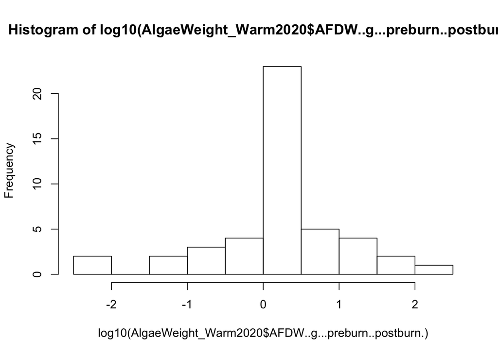

```r
#still not normal

#It is severe skewed so we can do a log10 transformation
hist(log10(AlgaeWeight_Warm2020$AFDW..g...preburn..postburn.))
```

```r
shapiro.test(AlgaeWeight_Warm2020$AFDW..g...preburn..postburn.)
```

```
##
##  Shapiro-Wilk normality test
##
## data:  AlgaeWeight_Warm2020$AFDW..g...preburn..postburn.
## W = 0.40474, p-value = 2.072e-12
```

```r
shapiro.test(sqrt(AlgaeWeight_Warm2020$AFDW..g...preburn..postburn.))
```

```
##
##  Shapiro-Wilk normality test
##
## data:  sqrt(AlgaeWeight_Warm2020$AFDW..g...preburn..postburn.)
## W = 0.68267, p-value = 1.089e-08
```

Even after transformation data does not seems to resemble normality so we should not use an Anova or any other parametric test.

### Determine effect of herbivory and nutriend addition using a GLM

```r
# Let's try with a  glm using a gamma distribution.

cold_season_model_gamma <- glm((AFDW..g...preburn..postburn.) ~ Treatment * N, family = Gamma(link = "log"), data = AlgaeWeight_Cold2019)
summary(cold_season_model_gamma)
```

```
##
## Call:
## glm(formula = (AFDW..g...preburn..postburn.) ~ Treatment * N,
##     family = Gamma(link = "log"), data = AlgaeWeight_Cold2019)
##
## Deviance Residuals:
##     Min       1Q   Median       3Q      Max
## -2.5317  -0.9077  -0.2737   0.4406   2.2261
##
## Coefficients:
##                                              Estimate Std. Error t value
## (Intercept)                                  -0.06953    0.41742  -0.167
## TreatmentFish exclusions                      2.44523    0.56884   4.299
## TreatmentFull exclusions                      2.25020    0.55219   4.075
## NNutrient additions                           1.19651    0.53888   2.220
## TreatmentFish exclusions:NNutrient additions -1.74559    0.75526  -2.311
## TreatmentFull exclusions:NNutrient additions -1.70400    0.74280  -2.294
##                                              Pr(>|t|)
## (Intercept)                                  0.868548
## TreatmentFish exclusions                     0.000107 ***
## TreatmentFull exclusions                     0.000212 ***
## NNutrient additions                          0.032124 *
## TreatmentFish exclusions:NNutrient additions 0.026054 *
## TreatmentFull exclusions:NNutrient additions 0.027119 *
## ---
## Signif. codes:  0 '***' 0.001 '**' 0.01 '*' 0.05 '.' 0.1 ' ' 1
##
## (Dispersion parameter for Gamma family taken to be 1.045423)
##
##     Null deviance: 69.637  on 45  degrees of freedom
## Residual deviance: 49.792  on 40  degrees of freedom
## AIC: 250.03
##
## Number of Fisher Scoring iterations: 6
```

```r
# Let's build a similar model without the interaction
cold_season_model_gamma_NI<-glm((AFDW..g...preburn..postburn.) ~ Treatment + N, family = Gamma(link = "log"), data = AlgaeWeight_Cold2019)
summary(cold_season_model_gamma_NI)
```

```
##
## Call:
## glm(formula = (AFDW..g...preburn..postburn.) ~ Treatment + N,
##     family = Gamma(link = "log"), data = AlgaeWeight_Cold2019)
##
## Deviance Residuals:
##      Min        1Q    Median        3Q       Max
## -2.43991  -0.99077  -0.39172   0.06863   2.89326
##
## Coefficients:
##                          Estimate Std. Error t value Pr(>|t|)
## (Intercept)               0.84752    0.40322   2.102  0.04160 *
## TreatmentFish exclusions  1.29595    0.46998   2.757  0.00859 **
## TreatmentFull exclusions  1.13311    0.46347   2.445  0.01877 *
## NNutrient additions      -0.05714    0.38176  -0.150  0.88175
## ---
## Signif. codes:  0 '***' 0.001 '**' 0.01 '*' 0.05 '.' 0.1 ' ' 1
##
## (Dispersion parameter for Gamma family taken to be 1.651752)
##
##     Null deviance: 69.637  on 45  degrees of freedom
## Residual deviance: 56.446  on 42  degrees of freedom
## AIC: 252.81
##
## Number of Fisher Scoring iterations: 10
```

```r
#Comparing models with and without interaction
anova(cold_season_model_gamma, cold_season_model_gamma_NI, test = 'Chisq')
```

|  | Resid. Df | Resid. Dev | Df | Deviance | Pr(>Chi) |
| --- | --- | --- | --- | --- | --- |
| 1 | 40 | 49.79172 | NA | NA | NA |
| 2 | 42 | 56.44586 | -2 | -6.654149 | 0.04148113 |

```r
anova(cold_season_model_gamma, test = 'Chisq')
```

|  | Df | Deviance | Resid. Df | Resid. Dev | Pr(>Chi) |
| --- | --- | --- | --- | --- | --- |
| NULL | NA | NA | 45 | 69.63677 | NA |
| Treatment | 2 | 13.16010297 | 43 | 56.47666 | 0.001847069 |
| N | 1 | 0.03079754 | 42 | 56.44586 | 0.863722551 |
| Treatment:N | 2 | 6.65414918 | 40 | 49.79172 | 0.041481129 |

```r
##Building a similar model for the warm season

# need to remove Fish exclusions here before running model
AlgaeWeight_Warm2020_fishRM <- AlgaeWeight_Warm2020 %>%
  filter(Treatment %in% c("Open pizzas", "Full exclusions")) %>%
  droplevels()

warm_season_model_gamma <- glm((AFDW..g...preburn..postburn.) ~ Treatment * N, family = Gamma(link="log"), data = AlgaeWeight_Warm2020_fishRM)
summary(warm_season_model_gamma)
```

```
##
## Call:
## glm(formula = (AFDW..g...preburn..postburn.) ~ Treatment * N,
##     family = Gamma(link = "log"), data = AlgaeWeight_Warm2020_fishRM)
##
## Deviance Residuals:
##     Min       1Q   Median       3Q      Max
## -2.9923  -1.5734  -0.5518   0.5115   1.8936
##
## Coefficients:
##                                              Estimate Std. Error t value
## (Intercept)                                    2.0308     0.4777   4.251
## TreatmentFull exclusions                      -0.9824     0.6542  -1.502
## NNutrient additions                           -1.6298     0.6542  -2.491
## TreatmentFull exclusions:NNutrient additions   3.9680     0.9251   4.289
##                                              Pr(>|t|)
## (Intercept)                                  0.000242 ***
## TreatmentFull exclusions                     0.145223
## NNutrient additions                          0.019430 *
## TreatmentFull exclusions:NNutrient additions 0.000219 ***
## ---
## Signif. codes:  0 '***' 0.001 '**' 0.01 '*' 0.05 '.' 0.1 ' ' 1
##
## (Dispersion parameter for Gamma family taken to be 1.597676)
##
##     Null deviance: 98.041  on 29  degrees of freedom
## Residual deviance: 59.915  on 26  degrees of freedom
## AIC: 164.2
##
## Number of Fisher Scoring iterations: 8
```

### Putting results from gamma model in a table

```r
#Let's build the table for the model with the gamma distribution
summary(cold_season_model_gamma)
```

```
##
## Call:
## glm(formula = (AFDW..g...preburn..postburn.) ~ Treatment * N,
##     family = Gamma(link = "log"), data = AlgaeWeight_Cold2019)
##
## Deviance Residuals:
##     Min       1Q   Median       3Q      Max
## -2.5317  -0.9077  -0.2737   0.4406   2.2261
##
## Coefficients:
##                                              Estimate Std. Error t value
## (Intercept)                                  -0.06953    0.41742  -0.167
## TreatmentFish exclusions                      2.44523    0.56884   4.299
## TreatmentFull exclusions                      2.25020    0.55219   4.075
## NNutrient additions                           1.19651    0.53888   2.220
## TreatmentFish exclusions:NNutrient additions -1.74559    0.75526  -2.311
## TreatmentFull exclusions:NNutrient additions -1.70400    0.74280  -2.294
##                                              Pr(>|t|)
## (Intercept)                                  0.868548
## TreatmentFish exclusions                     0.000107 ***
## TreatmentFull exclusions                     0.000212 ***
## NNutrient additions                          0.032124 *
## TreatmentFish exclusions:NNutrient additions 0.026054 *
## TreatmentFull exclusions:NNutrient additions 0.027119 *
## ---
## Signif. codes:  0 '***' 0.001 '**' 0.01 '*' 0.05 '.' 0.1 ' ' 1
##
## (Dispersion parameter for Gamma family taken to be 1.045423)
##
##     Null deviance: 69.637  on 45  degrees of freedom
## Residual deviance: 49.792  on 40  degrees of freedom
## AIC: 250.03
##
## Number of Fisher Scoring iterations: 6
```

```r
Estimate<-coef(summary(cold_season_model_gamma))[,1]
Std.Error<-coef(summary(cold_season_model_gamma))[,2]
t.value<-coef(summary(cold_season_model_gamma))[,3]
P.value<-coef(summary(cold_season_model_gamma))[,4]
Treatment<-c("(Intercept)", "Urchin acces", "Full exclusions", "Nutrient additions", "Urchin access x Nutrient additions", "Full exclusions x Nutrient additions")

cold_gamma_table<-data.frame(Treatment, Estimate, Std.Error, t.value, P.value)

cold_gamma_table$Signif.<-ifelse(cold_gamma_table$P.value<0.05, "*", "")
#cold_gamma_table$Signif.<-ifelse(cold_gamma_table$P.value<0.01 & cold_gamma_table$P.value>0.001, "**", "")
#cold_gamma_table$Signif.<-ifelse(cold_gamma_table$P.value<0.001, "***", "")

cold_gamma_table<-cold_gamma_table %>%
  mutate_if(is.numeric, round, digits=3)

cold_gamma_table$P.value[cold_gamma_table$P.value<=0.05]<-">0.05"
#cold_gamma_table$P.value[cold_gamma_table$P.value<=0.01 & cold_gamma_table$P.value > 0.001 ]<-">0.01"
#cold_gamma_table$P.value[cold_gamma_table$P.value<=0.001]<-">0.001"

cold_gamma_table<- flextable(cold_gamma_table)
cold_gamma_table<-autofit(cold_gamma_table)
cold_gamma_table<-font(cold_gamma_table, fontname = "Times", part = "header")
cold_gamma_table<-font(cold_gamma_table, fontname = "Times")
cold_gamma_table <- add_header_lines(cold_gamma_table, values = "Cold season")
save_as_image(cold_gamma_table, path = "cold_gamma_table.png")
```

```
## [1] "/Users/colleen/Dropbox/Git/PizzaProject_2019-2020/cold_gamma_table.png"
```

```r
cold_gamma_table
```

| Cold season Treatment | Cold season Estimate | Cold season Std.Error | Cold season t.value | Cold season P.value | Cold season Signif. |
| --- | --- | --- | --- | --- | --- |
| (Intercept) | -0.070 | 0.417 | -0.167 | 0.869 |  |
| Urchin acces | 2.445 | 0.569 | 4.299 | >0.05 |  |
| Full exclusions | 2.250 | 0.552 | 4.075 | >0.05 |  |
| Nutrient additions | 1.197 | 0.539 | 2.220 | >0.05 |  |
| Urchin access x Nutrient additions | -1.746 | 0.755 | -2.311 | >0.05 |  |
| Full exclusions x Nutrient additions | -1.704 | 0.743 | -2.294 | >0.05 |  |

```r
#Let's do the same for the warm season

summary(warm_season_model_gamma)
```

```
##
## Call:
## glm(formula = (AFDW..g...preburn..postburn.) ~ Treatment * N,
##     family = Gamma(link = "log"), data = AlgaeWeight_Warm2020_fishRM)
##
## Deviance Residuals:
##     Min       1Q   Median       3Q      Max
## -2.9923  -1.5734  -0.5518   0.5115   1.8936
##
## Coefficients:
##                                              Estimate Std. Error t value
## (Intercept)                                    2.0308     0.4777   4.251
## TreatmentFull exclusions                      -0.9824     0.6542  -1.502
## NNutrient additions                           -1.6298     0.6542  -2.491
## TreatmentFull exclusions:NNutrient additions   3.9680     0.9251   4.289
##                                              Pr(>|t|)
## (Intercept)                                  0.000242 ***
## TreatmentFull exclusions                     0.145223
## NNutrient additions                          0.019430 *
## TreatmentFull exclusions:NNutrient additions 0.000219 ***
## ---
## Signif. codes:  0 '***' 0.001 '**' 0.01 '*' 0.05 '.' 0.1 ' ' 1
##
## (Dispersion parameter for Gamma family taken to be 1.597676)
##
##     Null deviance: 98.041  on 29  degrees of freedom
## Residual deviance: 59.915  on 26  degrees of freedom
## AIC: 164.2
##
## Number of Fisher Scoring iterations: 8
```

```r
Estimate<-coef(summary(warm_season_model_gamma))[,1]
Std.Error<-coef(summary(warm_season_model_gamma))[,2]
t.value<-coef(summary(warm_season_model_gamma))[,3]
P.value<-coef(summary(warm_season_model_gamma))[,4]
Treatment<-c("(Intercept)", "Full exclusions", "Nutrient additions", "Full exclusions x Nutrient additions")
#Treatment<-c("(Intercept)", "Urchin acces", "Full exclusions", "Nutrient additions", "Urchin access x Nutrient additions", "Full exclusions x Nutrient additions")

warm_gamma_table<-data.frame(Treatment, Estimate, Std.Error, t.value, P.value)

warm_gamma_table$Signif.<-ifelse(warm_gamma_table$P.value<0.05, "*", "")

warm_gamma_table<-warm_gamma_table %>%
  mutate_if(is.numeric, round, digits=3)

warm_gamma_table$P.value[warm_gamma_table$P.value<=0.05]<-">0.05"
#warm_anova_table$P.value[warm_anova_table$P.value<=0.01]<-">0.01"

warm_gamma_table<- flextable(warm_gamma_table)
warm_gamma_table<-autofit(warm_gamma_table)
warm_gamma_table<-font(warm_gamma_table, fontname = "Times", part = "header")
warm_gamma_table<-font(warm_gamma_table, fontname = "Times")
warm_gamma_table <- add_header_lines(warm_gamma_table, values = "Warm season")
save_as_image(warm_gamma_table, path = "warm_gamma_table.png")
```

```
## [1] "/Users/colleen/Dropbox/Git/PizzaProject_2019-2020/warm_gamma_table.png"
```

```r
warm_gamma_table
```

| Warm season Treatment | Warm season Estimate | Warm season Std.Error | Warm season t.value | Warm season P.value | Warm season Signif. |
| --- | --- | --- | --- | --- | --- |
| (Intercept) | 2.031 | 0.478 | 4.251 | >0.05 |  |
| Full exclusions | -0.982 | 0.654 | -1.502 | 0.145 |  |
| Nutrient additions | -1.630 | 0.654 | -2.491 | >0.05 |  |
| Full exclusions x Nutrient additions | 3.968 | 0.925 | 4.289 | >0.05 |  |